# TX_PRIDE

DSIP PRIDE project

Goal is to link geocoded data of known super fund sites to see if there is a correlation between Parkinson and/or other serious illnesses, such as cancer, and how close the patient lives to a super fund site.

Applying data downloaded from the Texas Patient Database project

Hospital Discharge data by quarter: https://www.dshs.texas.gov/THCIC/Hospitals/Download.shtm

Outpatient Discharge data by quarter: https://www.dshs.texas.gov/thcic/Outpatient-Discharge-Data-Public-Use-Data-File/

Hypothesis: Patients with a zip code area that includes a superfund site will have a statistically significant difference in percentage of citizens treated for Parkinsons, compared to other zip code areas.

Approach: 1) Download both hospital and outpatient discharge data for 2 years, 8 quarters 2) Find % of total records with a Parkinson diagnosis by zip code 3) Identify which zip codes have a super fund site 4) Merge files: [zip_code, Pct_ParkinsonDiagnosis, Superfund_YN] 5) Split records by whether there is a Superfund site 6) Compare the percent of Parkinson patients within the two groups

Phase 2:

- Consider age, gender and ethnicity for differences.
- Investigate using the Texas Patient Database for predicating likelihood of someone having a serious illness based on their zip code, age, gender and ethnicity.

Below is a start at Exploratory Data Analysis looking at the Texas Patient Data for Q1 2014

```python
import pandas as pd
import seaborn as sn
```

```python
# Read in the Texas Q1 2014 Outpatient data

oppudf = pd.read_csv("OP_PUDF_base1q2014_tab.txt", sep = '\t',
                     dtype ={'PAT_AGE':'str',
                             'PRINC_DIAG_CODE': 'str'})
```

```python
# Describe the Principle Diagnostic Code

oppudf.PRINC_DIAG_CODE.describe()
```

```
count     2951366
unique       9056
top         V7612
freq       212030
Name: PRINC_DIAG_CODE, dtype: object
```

```python
oppudf.columns
```

```
Index(['SERVICE_QUARTER', 'RECORD_ID', 'THCIC_ID', 'PROVIDER_NAME',
       'SPEC_UNIT', 'SEX_CODE', 'PAT_COUNTY', 'PAT_STATE', 'PAT_ZIP',
       'PAT_COUNTRY',
       ...
       'ESRD_AMOUNT', 'CLINIC_AMOUNT', 'TOTAL_CHARGES',
       'TOTAL_NON_COV_CHARGES', 'TOTAL_CHARGES_ANCIL',
       'TOTAL_NON_COV_CHARGES_ANCIL', 'PHYSICIAN1_INDEX_NUMBER',
       'PHYSICIAN2_INDEX_NUMBER', 'CERT_STATUS', 'INPUT_FORMAT'],
      dtype='object', length=123)
```

```python
# Read in the Texas Q1 2014 Outpatient Classification data

opclass = pd.read_csv("OP_Classification1q2014_tab.txt", sep = '\t')
```

```python
opclass.columns
```

```
Index(['RECORD_ID', 'CCS_PRINC_DIAG_CODE', 'CCS_OTH_DIAG_CODE_1',
       'CCS_OTH_DIAG_CODE_2', 'CCS_OTH_DIAG_CODE_3', 'CCS_OTH_DIAG_CODE_4',
       'CCS_OTH_DIAG_CODE_5', 'CCS_OTH_DIAG_CODE_6', 'CCS_OTH_DIAG_CODE_7',
       'CCS_OTH_DIAG_CODE_8',
       ...
       'APC_WEIGHT_3', 'APC_WEIGHT_4', 'APC_WEIGHT_5', 'APC_WEIGHT_6',
       'APC_WEIGHT_7', 'APC_WEIGHT_8', 'APC_WEIGHT_9', 'APC_WEIGHT_10',
       'APC_GRP_VER', 'Unnamed: 143'],
      dtype='object', length=144)
```

```python
# Parkinson's disease (332.0)
oppudf[oppudf.PRINC_DIAG_CODE == '3320'].describe()
```

|  | RECORD_ID | THCIC_ID | PAT_COUNTY | PUBLIC_HEALTH_REGION | TYPE_OF_BILL | CONDITION_CODE_7 | CONDITION_CODE_8 | E_CODE_8 | E_CODE_9 | E_CODE_10 | ... | ESRD_AMOUNT | CLINIC_AMOUNT | TOTAL_CHARGES | TOTAL_NON_COV_CHARGES | TOTAL_CHARGES_ANCIL | TOTAL_NON_COV_CHARGES_ANCIL | PHYSICIAN1_INDEX_NUMBER | PHYSICIAN2_INDEX_NUMBER | CERT_STATUS | INPUT_FORMAT |
| --- | --- | --- | --- | --- | --- | --- | --- | --- | --- | --- | --- | --- | --- | --- | --- | --- | --- | --- | --- | --- | --- |
| count | 6.490000e+02 | 649.000000 | 621.000000 | 621.000000 | 649.000000 | 0.0 | 0.0 | 0.0 | 0.0 | 0.0 | ... | 649.0 | 649.000000 | 649.000000 | 649.0 | 649.000000 | 649.000000 | 8.000000e+01 | 3.360000e+02 | 649.000000 | 649.0 |
| mean | 1.201422e+11 | 401498.704160 | 228.297907 | 5.732689 | 140.907550 | NaN | NaN | NaN | NaN | NaN | ... | 0.0 | 3.896425 | 14994.957119 | 0.0 | 14997.307812 | 56.896656 | 3.819587e+09 | 4.563542e+09 | 1.847458 | 1.0 |
| std | 9.084830e+05 | 233153.591026 | 136.013270 | 2.569557 | 83.488693 | NaN | NaN | NaN | NaN | NaN | ... | 0.0 | 29.007528 | 30992.578413 | 0.0 | 30991.622910 | 714.420358 | 2.930294e+09 | 2.824743e+09 | 1.613933 | 0.0 |
| min | 1.201401e+11 | 102.000000 | 1.000000 | 1.000000 | 131.000000 | NaN | NaN | NaN | NaN | NaN | ... | 0.0 | 0.000000 | 55.250000 | 0.0 | 55.250000 | 0.000000 | 1.113032e+09 | 1.003507e+09 | 1.000000 | 1.0 |
| 25% | 1.201416e+11 | 235000.000000 | 113.000000 | 3.000000 | 131.000000 | NaN | NaN | NaN | NaN | NaN | ... | 0.0 | 0.000000 | 2798.000000 | 0.0 | 2798.000000 | 0.000000 | 1.632223e+09 | 2.009948e+09 | 1.000000 | 1.0 |
| 50% | 1.201422e+11 | 398001.000000 | 201.000000 | 6.000000 | 131.000000 | NaN | NaN | NaN | NaN | NaN | ... | 0.0 | 0.000000 | 4791.000000 | 0.0 | 4791.000000 | 0.000000 | 1.876387e+09 | 4.221984e+09 | 1.000000 | 1.0 |
| 75% | 1.201428e+11 | 508001.000000 | 339.000000 | 7.000000 | 131.000000 | NaN | NaN | NaN | NaN | NaN | ... | 0.0 | 0.000000 | 9396.760000 | 0.0 | 9396.760000 | 0.000000 | 5.168413e+09 | 7.140906e+09 | 2.000000 | 1.0 |
| max | 1.201438e+11 | 971900.000000 | 499.000000 | 11.000000 | 851.000000 | NaN | NaN | NaN | NaN | NaN | ... | 0.0 | 370.000000 | 208671.760000 | 0.0 | 208671.760000 | 13999.950000 | 1.000000e+10 | 1.000000e+10 | 6.000000 | 1.0 |

8 rows × 43 columns

```python
# dementia with Parkinsonism (331.82)

oppudf[oppudf.PRINC_DIAG_CODE == '33182'].describe()
```

|  | RECORD_ID | THCIC_ID | PAT_COUNTY | PUBLIC_HEALTH_REGION | TYPE_OF_BILL | CONDITION_CODE_7 | CONDITION_CODE_8 | E_CODE_8 | E_CODE_9 | E_CODE_10 | ... | ESRD_AMOUNT | CLINIC_AMOUNT | TOTAL_CHARGES | TOTAL_NON_COV_CHARGES | TOTAL_CHARGES_ANCIL | TOTAL_NON_COV_CHARGES_ANCIL | PHYSICIAN1_INDEX_NUMBER | PHYSICIAN2_INDEX_NUMBER | CERT_STATUS | INPUT_FORMAT |
| --- | --- | --- | --- | --- | --- | --- | --- | --- | --- | --- | --- | --- | --- | --- | --- | --- | --- | --- | --- | --- | --- |
| count | 4.000000e+01 | 40.000000 | 40.000000 | 40.000000 | 40.000000 | 0.0 | 0.0 | 0.0 | 0.0 | 0.0 | ... | 40.0 | 40.0 | 40.000000 | 40.0 | 40.000000 | 40.000000 | 8.000000e+00 | 1.600000e+01 | 40.000000 | 40.0 |
| mean | 1.201421e+11 | 400085.200000 | 233.600000 | 5.025000 | 167.000000 | NaN | NaN | NaN | NaN | NaN | ... | 0.0 | 0.0 | 9517.879000 | 0.0 | 9517.879000 | 193.151000 | 3.833384e+09 | 4.271045e+09 | 1.500000 | 1.0 |
| std | 9.855429e+05 | 271437.080382 | 140.687834 | 2.586826 | 158.919428 | NaN | NaN | NaN | NaN | NaN | ... | 0.0 | 0.0 | 9496.475087 | 0.0 | 9496.475087 | 580.033515 | 2.772008e+09 | 3.025036e+09 | 0.877058 | 0.0 |
| min | 1.201401e+11 | 1000.000000 | 27.000000 | 1.000000 | 131.000000 | NaN | NaN | NaN | NaN | NaN | ... | 0.0 | 0.0 | 323.400000 | 0.0 | 323.400000 | 0.000000 | 1.244989e+09 | 1.018329e+09 | 1.000000 | 1.0 |
| 25% | 1.201416e+11 | 204500.000000 | 113.000000 | 3.000000 | 131.000000 | NaN | NaN | NaN | NaN | NaN | ... | 0.0 | 0.0 | 3500.200000 | 0.0 | 3500.200000 | 0.000000 | 2.397188e+09 | 1.681120e+09 | 1.000000 | 1.0 |
| 50% | 1.201420e+11 | 339000.000000 | 201.000000 | 4.000000 | 131.000000 | NaN | NaN | NaN | NaN | NaN | ... | 0.0 | 0.0 | 7064.080000 | 0.0 | 7064.080000 | 0.000000 | 2.844251e+09 | 3.432388e+09 | 1.000000 | 1.0 |
| 75% | 1.201429e+11 | 525000.000000 | 362.500000 | 6.000000 | 131.000000 | NaN | NaN | NaN | NaN | NaN | ... | 0.0 | 0.0 | 10741.427500 | 0.0 | 10741.427500 | 0.000000 | 4.216015e+09 | 5.534178e+09 | 2.000000 | 1.0 |
| max | 1.201438e+11 | 971900.000000 | 499.000000 | 11.000000 | 851.000000 | NaN | NaN | NaN | NaN | NaN | ... | 0.0 | 0.0 | 41708.030000 | 0.0 | 41708.030000 | 1927.000000 | 1.000000e+10 | 1.000000e+10 | 6.000000 | 1.0 |

8 rows × 43 columns

```python
# 332.1	Secondary Parkinsonism Neuroleptic-induced Parkinsonism; Parkinsonism due to drugs
oppudf[oppudf.PRINC_DIAG_CODE == '3321'].describe()
```

|  | RECORD_ID | THCIC_ID | PAT_COUNTY | PUBLIC_HEALTH_REGION | TYPE_OF_BILL | CONDITION_CODE_7 | CONDITION_CODE_8 | E_CODE_8 | E_CODE_9 | E_CODE_10 | ... | ESRD_AMOUNT | CLINIC_AMOUNT | TOTAL_CHARGES | TOTAL_NON_COV_CHARGES | TOTAL_CHARGES_ANCIL | TOTAL_NON_COV_CHARGES_ANCIL | PHYSICIAN1_INDEX_NUMBER | PHYSICIAN2_INDEX_NUMBER | CERT_STATUS | INPUT_FORMAT |
| --- | --- | --- | --- | --- | --- | --- | --- | --- | --- | --- | --- | --- | --- | --- | --- | --- | --- | --- | --- | --- | --- |
| count | 2.200000e+01 | 22.000000 | 22.000000 | 22.000000 | 22.0 | 0.0 | 0.0 | 0.0 | 0.0 | 0.0 | ... | 22.0 | 22.0 | 22.000000 | 22.0 | 22.000000 | 22.0 | 1.000000e+00 | 1.400000e+01 | 22.000000 | 22.0 |
| mean | 1.201424e+11 | 427322.818182 | 187.636364 | 6.363636 | 131.0 | NaN | NaN | NaN | NaN | NaN | ... | 0.0 | 0.0 | 4394.376818 | 0.0 | 4394.376818 | 0.0 | 1.738047e+09 | 3.914693e+09 | 1.590909 | 1.0 |
| std | 8.034750e+05 | 261784.401782 | 97.512659 | 2.479352 | 0.0 | NaN | NaN | NaN | NaN | NaN | ... | 0.0 | 0.0 | 3574.241422 | 0.0 | 3574.241422 | 0.0 | NaN | 2.420555e+09 | 1.469016 | 0.0 |
| min | 1.201414e+11 | 130000.000000 | 27.000000 | 1.000000 | 131.0 | NaN | NaN | NaN | NaN | NaN | ... | 0.0 | 0.0 | 201.000000 | 0.0 | 201.000000 | 0.0 | 1.738047e+09 | 1.009419e+09 | 1.000000 | 1.0 |
| 25% | 1.201416e+11 | 187275.000000 | 141.000000 | 6.000000 | 131.0 | NaN | NaN | NaN | NaN | NaN | ... | 0.0 | 0.0 | 1828.500000 | 0.0 | 1828.500000 | 0.0 | 1.738047e+09 | 1.639699e+09 | 1.000000 | 1.0 |
| 50% | 1.201421e+11 | 343000.500000 | 179.000000 | 6.000000 | 131.0 | NaN | NaN | NaN | NaN | NaN | ... | 0.0 | 0.0 | 3207.375000 | 0.0 | 3207.375000 | 0.0 | 1.738047e+09 | 4.244617e+09 | 1.000000 | 1.0 |
| 75% | 1.201431e+11 | 701825.250000 | 220.500000 | 8.000000 | 131.0 | NaN | NaN | NaN | NaN | NaN | ... | 0.0 | 0.0 | 6311.000000 | 0.0 | 6311.000000 | 0.0 | 1.738047e+09 | 5.640686e+09 | 1.000000 | 1.0 |
| max | 1.201438e+11 | 843200.000000 | 439.000000 | 10.000000 | 131.0 | NaN | NaN | NaN | NaN | NaN | ... | 0.0 | 0.0 | 14019.000000 | 0.0 | 14019.000000 | 0.0 | 1.738047e+09 | 8.254583e+09 | 6.000000 | 1.0 |

8 rows × 43 columns

```python
# Count the records by Principle Diagnostic Code

diagcount = oppudf.groupby(by = "PRINC_DIAG_CODE").agg({'RECORD_ID':'nunique'})
```

```python
diagcount.sort_values('RECORD_ID',ascending = False).head(10)
```

| PRINC_DIAG_CODE | RECORD_ID |
| --- | --- |
| V7612 | 212030 |
| V7651 | 51166 |
| 78650 | 43076 |
| 78900 | 40137 |
| 36616 | 30798 |
| 7840 | 29786 |
| 78659 | 29093 |
| 99ERR | 29067 |
| 71946 | 26888 |
| 7295 | 26042 |

```python
diagcount = diagcount.reset_index()
```

```python
diagcount.head()
```

|  | PRINC_DIAG_CODE | RECORD_ID |
| --- | --- | --- |
| 0 | 0000 | 4 |
| 1 | 00000 | 51 |
| 2 | 0011 | 1 |
| 3 | 0030 | 5 |
| 4 | 0039 | 1 |

```python
# PRINC_DIAG_CODE ICD-9-CM diagnosis code for the principal diagnosis,
# including the 4th and 5th digits if applicable.
# Decimal is implied following the third character.

# to find the code meaning used: https://www.cdc.gov/nchs/icd/icd9cm.htm#ftp

park_disease = diagcount[diagcount.PRINC_DIAG_CODE == '3320'].RECORD_ID.sum()
park_dementia = diagcount[diagcount.PRINC_DIAG_CODE == '33182'].RECORD_ID.sum()
park_induced = diagcount[diagcount.PRINC_DIAG_CODE == '3321'].RECORD_ID.sum()
```

```python
total_unique_records = diagcount.RECORD_ID.sum()
```

```python
total_unique_records
```

```
2951366
```

```python
pct_park = (park_disease + park_dementia + park_induced)/total_unique_records
print("Parkinson diagnosis:",round(pct_park*100,3),'%')
```

```
Parkinson diagnosis: 0.024 %
```

```python
# HEREDITARY AND DEGENERATIVE DISEASES OF THE CENTRAL NERVOUS SYSTEM (330-337)

ex3_disease = diagcount[diagcount['PRINC_DIAG_CODE'].str.startswith('33')].RECORD_ID.sum()
pct_ex3 = ex3_disease/total_unique_records
print("Central Nervous System diagnosis:",round(pct_ex3*100,3),'%')
```

```
Central Nervous System diagnosis: 0.556 %
```

```python
# Top outpatient code: mammograms
# V76.12	Other screening mammogram
max_disease = diagcount[diagcount.PRINC_DIAG_CODE == 'V7612'].RECORD_ID.sum()
pct_max = max_disease/total_unique_records
print("Top Code: Mammograms", round(pct_max*100,3),'%')
```

```
Top Code: Mammograms 7.184 %
```

```python
# 786.50	Chest pain, unspecified
ex_disease = diagcount[diagcount.PRINC_DIAG_CODE == '78650'].RECORD_ID.sum()
pct_ex = ex_disease/total_unique_records
print("Chest pain unspecified",round(pct_ex*100,3),'%')
```

```
Chest pain unspecified 1.46 %
```

```python
# Cancer codes...
# MALIGNANT NEOPLASM OF LYMPHATIC AND HEMATOPOIETIC TISSUE (200-208)
# NEUROENDOCRINE TUMORS (209)

ex2_disease = diagcount[diagcount['PRINC_DIAG_CODE'].str.startswith('20')].RECORD_ID.sum()
pct_ex2 = ex2_disease/total_unique_records
print("Cancer", round(pct_ex2*100,3),'%')
```

```
Cancer 0.584 %
```

```python
diagcount2 = oppudf.groupby(["PRINC_DIAG_CODE", "PAT_COUNTY", "PAT_ZIP", "PAT_AGE", "ETHNICITY", "RACE"]).agg({'RECORD_ID':'nunique'})
```

```python
diagcount2 = diagcount2.reset_index()
```

```python
diagcount2.columns = ['PRINC_DIAG_CODE','PAT_COUNTY', 'PAT_ZIP','PAT_AGE','ETHNICITY','RACE','Record_count']
diagcount2
```

|  | PRINC_DIAG_CODE | PAT_COUNTY | PAT_ZIP | PAT_AGE | ETHNICITY | RACE | Record_count |
| --- | --- | --- | --- | --- | --- | --- | --- |
| 0 | 0000 | 29.0 | 78217 | 08 | 2 | 4 | 1 |
| 1 | 0000 | 29.0 | 78221 | 07 | 1 | 4 | 1 |
| 2 | 0000 | 29.0 | 78233 | 17 | 2 | 3 | 1 |
| 3 | 0000 | 29.0 | 78242 | 18 | 1 | 4 | 1 |
| 4 | 00000 | 29.0 | 78002 | 13 | 1 | 4 | 1 |
| ... | ... | ... | ... | ... | ... | ... | ... |
| 2121553 | V9103 | 309.0 | 76706 | 08 | 1 | 5 | 1 |
| 2121554 | V9103 | 309.0 | 76707 | 07 | 2 | 4 | 1 |
| 2121555 | V9103 | 309.0 | 76712 | 08 | 2 | 4 | 1 |
| 2121556 | V9103 | 439.0 | 76244 | 08 | 2 | 3 | 1 |
| 2121557 | V9103 | 491.0 | 76530 | 09 | 2 | 4 | 3 |

2121558 rows × 7 columns

```python
diagcount2[diagcount2['PRINC_DIAG_CODE'].str.startswith('33')]
```

|  | PRINC_DIAG_CODE | PAT_COUNTY | PAT_ZIP | PAT_AGE | ETHNICITY | RACE | Record_count |
| --- | --- | --- | --- | --- | --- | --- | --- |
| 217376 | 3300 | 27.0 | 76513 | 03 | 2 | 4 | 1 |
| 217377 | 3300 | 37.0 | 75574 | 14 | 2 | 4 | 1 |
| 217378 | 3300 | 141.0 | 79902 | 13 | 1 | 4 | 1 |
| 217379 | 3300 | 201.0 | 77036 | 01 | 1 | 4 | 3 |
| 217380 | 3300 | 201.0 | 77082 | 03 | 2 | 3 | 1 |
| ... | ... | ... | ... | ... | ... | ... | ... |
| 231004 | 33989 | 479.0 | 78045 | 17 | 2 | 5 | 1 |
| 231005 | 33989 | 485.0 | 76301 | 04 | 2 | 4 | 1 |
| 231006 | 33989 | 485.0 | 76306 | 10 | 1 | 5 | 1 |
| 231007 | 33989 | 485.0 | 76367 | 11 | 2 | 4 | 1 |
| 231008 | 33989 | 491.0 | 78642 | 08 | 2 | 4 | 1 |

13633 rows × 7 columns

```python
diagcount2[diagcount2['PRINC_DIAG_CODE'].str.startswith('3320')]
```

|  | PRINC_DIAG_CODE | PAT_COUNTY | PAT_ZIP | PAT_AGE | ETHNICITY | RACE | Record_count |
| --- | --- | --- | --- | --- | --- | --- | --- |
| 219412 | 3320 | 1.0 | 75801 | 14 | 2 | 4 | 1 |
| 219413 | 3320 | 5.0 | 75901 | 14 | 2 | 5 | 1 |
| 219414 | 3320 | 5.0 | 75901 | 19 | 2 | 5 | 1 |
| 219415 | 3320 | 5.0 | 75941 | 16 | 2 | 5 | 1 |
| 219416 | 3320 | 19.0 | 78055 | 17 | 2 | 4 | 1 |
| ... | ... | ... | ... | ... | ... | ... | ... |
| 219953 | 3320 | 499.0 | 75773 | 19 | 2 | 4 | 1 |
| 219954 | 3320 | 499.0 | 75783 | 17 | 2 | 4 | 1 |
| 219955 | 3320 | 499.0 | 75765 | 17 | 2 | 4 | 1 |
| 219956 | 3320 | 499.0 | 75765 | 20 | 2 | 4 | 1 |
| 219957 | 3320 | 499.0 | 75773 | 17 | 2 | 4 | 1 |

546 rows × 7 columns

```python
park_records = diagcount2[diagcount2['PRINC_DIAG_CODE'].str.startswith('3320')]
```

```python
park_records.describe()
```

|  | PAT_COUNTY | Record_count |
| --- | --- | --- |
| count | 546.000000 | 546.000000 |
| mean | 226.706960 | 1.130037 |
| std | 137.852794 | 0.405846 |
| min | 1.000000 | 1.000000 |
| 25% | 113.000000 | 1.000000 |
| 50% | 201.000000 | 1.000000 |
| 75% | 339.000000 | 1.000000 |
| max | 499.000000 | 3.000000 |

```python
park_records.to_csv("park_records.csv")
```

```python
diagage = oppudf.groupby(["PAT_AGE"]).agg({'RECORD_ID':'nunique'})
```

```python
diagage.columns =['Record_count']
```

```python
pudf1 = pd.read_csv("PUDF_base1_1q2014_tab.txt", sep = '\t')
pudf2 = pd.read_csv("PUDF_base2_1q2014_tab.txt", sep = '\t')
```

```python
pudf1.columns
```

```
Index(['RECORD_ID', 'DISCHARGE', 'THCIC_ID', 'PROVIDER_NAME',
       'TYPE_OF_ADMISSION', 'SOURCE_OF_ADMISSION', 'SPEC_UNIT_1',
       'SPEC_UNIT_2', 'SPEC_UNIT_3', 'SPEC_UNIT_4',
       ...
       'APR_DRG', 'RISK_MORTALITY', 'ILLNESS_SEVERITY',
       'APR_GROUPER_VERSION_NBR', 'APR_GROUPER_ERROR_CODE',
       'ATTENDING_PHYSICIAN_UNIF_ID', 'OPERATING_PHYSICIAN_UNIF_ID',
       'ENCOUNTER_INDICATOR', 'CERT_STATUS', 'FILLER_SPACE'],
      dtype='object', length=194)
```

```python
pudf_age1 = pudf1.groupby(["PAT_AGE"]).agg({'RECORD_ID':'nunique'})
pudf_county1 = pudf1.groupby(["COUNTY"]).agg({'RECORD_ID':'nunique'})
#pudf_age2 = pudf2.groupby(["PAT_AGE"]).agg({'RECORD_ID':'nunique'})
```

```python
pudf_age1 = pudf_age1.reset_index()
pudf_county1 = pudf_county1.reset_index()
```

```python
pudf_county1_t10= pudf_county1.sort_values('RECORD_ID', ascending = False).head(10)
```

```
array([[<AxesSubplot:title={'center':'Record_count'}>]], dtype=object)
```

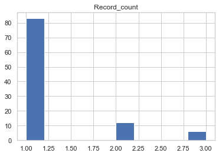

```python
park_records.groupby("PAT_COUNTY").agg({"Record_count":'nunique'}).hist()
```

```python
pat_county = park_records.groupby("PAT_COUNTY").agg({"RECORD_ID":'nunique'})
```

```python
pat_county = pat_county.reset_index()
```

```python
pat_county
```

|  | PAT_COUNTY | RECORD_ID |
| --- | --- | --- |
| 0 | 1.0 | 1 |
| 1 | 5.0 | 1 |
| 2 | 19.0 | 1 |
| 3 | 21.0 | 1 |
| 4 | 27.0 | 1 |
| ... | ... | ... |
| 96 | 485.0 | 1 |
| 97 | 489.0 | 1 |
| 98 | 491.0 | 3 |
| 99 | 493.0 | 1 |
| 100 | 499.0 | 1 |

101 rows × 2 columns

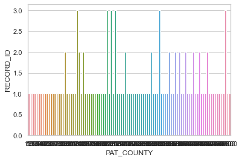

```python
sn.set_theme(style="whitegrid")
ax = sn.barplot(x='PAT_COUNTY', y='RECORD_ID', data = pat_county)
```

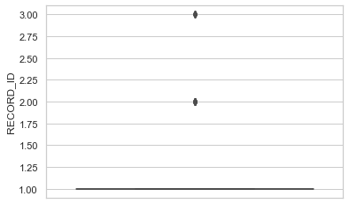

```python
ax = sn.boxplot(y='RECORD_ID', data = pat_county)
```

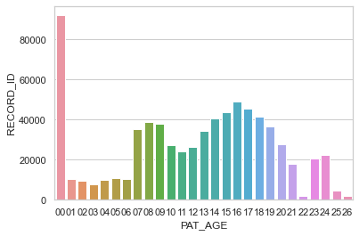

```python
# age groupings by count of claims in Q1 2014
ax = sn.barplot(x='PAT_AGE', y='RECORD_ID', data = pudf_age1)
```

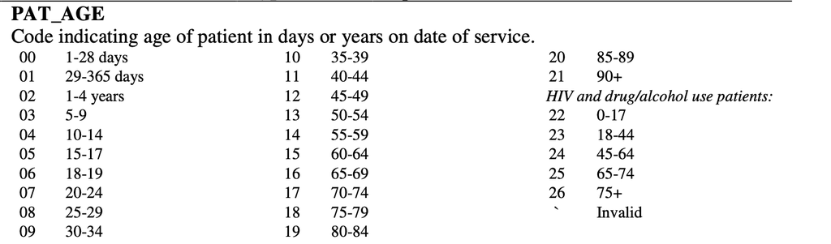

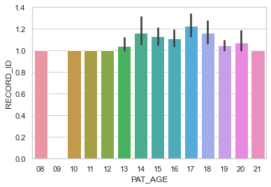

```python
# age groupings of Parkinson patients
ax = sn.barplot(x='PAT_AGE', y='RECORD_ID',
                order = ['08','09','10', '11', '12', '13', '14', '15', '16', '17', '18','19', '20', '21'],
                data = park_records)
```

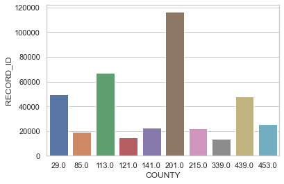

```python
# Top 10 counties with claims in Q12014
ax = sn.barplot(x='COUNTY', y='RECORD_ID', data = pudf_county1_t10)
```

```python
park_county_t10 = park_records.sort_values('RECORD_ID')
```

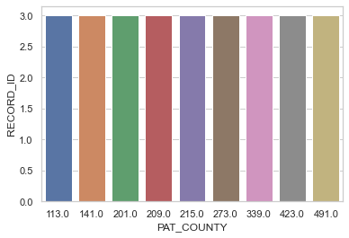

```python
# Counties with greater than 2 Parkinson claims in Q1 2014

ax = sn.barplot(x='PAT_COUNTY', y='RECORD_ID', data = park_records[park_records['RECORD_ID']>2])
```